# Praca domowa 2

Helena Maciątek

## Dane

Dane wykorzystane w Pracy domowej 2 dotyczą wyników egzaminów z 3 umiejętności: czytania, pisania i operacji matematycznych. Dodatkowo dostępne są podstawowe informacje o studentach i ich rodzicach. Opis wszystkich kolumn znajduje się również w pliku `README.md`.

| Zmienna | Opis |
| --- | --- |
| **gender** | płeć |
| **race.ethnicity** | pochodzenie etniczne |
| **parental.level.of.education** | wykształcenie rodziców |
| **lunch** | jaki obiad jedli uczniowie w dniu egzaminu |
| **test.preparation.course** | czy uczeń odbył kurs przygotowujący |
| **math.score** | wynik egzaminu z matematyki |
| **reading.score** | wynik egzaminu z czytania |
| **writing.score** | wynik egzaminu z pisania |

## Zadanie 1

Jak wyglądają rozkłady wyników uczniów z trzech przedmiotów (matematyka, czytanie, pisanie)?

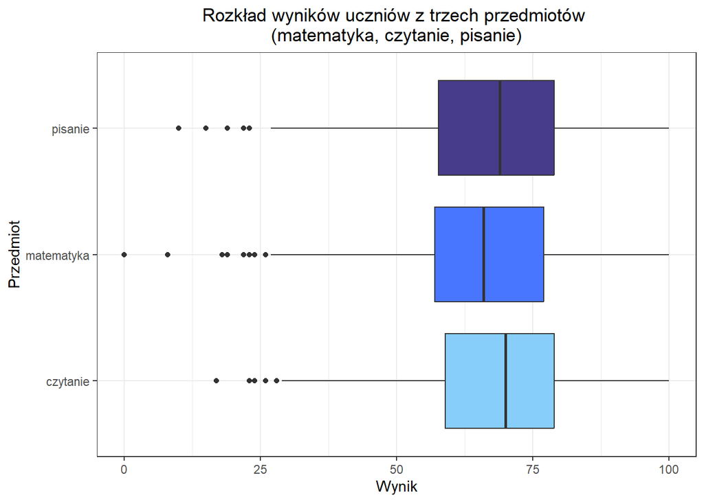

```r
df1 <- df %>%
  pivot_longer(c(math.score, reading.score, writing.score), names_to="przedmiot", values_to="wynik") %>%
  mutate(przedmiot = case_when(przedmiot == 'math.score'~'matematyka',
                                 przedmiot == 'reading.score' ~ 'czytanie',
                                 TRUE ~ 'pisanie'))

df1 %>%
  ggplot(aes(x=wynik, y=przedmiot, fill=przedmiot))+
  geom_boxplot()+
  labs(x="Wynik",
       y="Przedmiot",
       title="Rozkład wyników uczniów z trzech przedmiotów
(matematyka, czytanie, pisanie)")+
  scale_fill_manual(values = c('lightskyblue', 'royalblue1', 'slateblue4'))+
    theme_bw()+
  theme(legend.position = "none",
        plot.title = element_text(hjust = 0.5)) #chcę wyśrodkować tytuł, żeby był dobrze widoczny i estetycznie wyglądał w pliku html
```

**Komentarz:** Większość wyników z każdego przedmiotu jest w przedziale 60-80 punktów. Z czytania i pisania widać lekkie przesunięcie wyników w stronę tych lepszych, w porównaniu z matematyką. Z matematyki jest też więcej niskich wyników, niż z pozostałych dwóch przedmiotów.

## Zadanie 2

Czy istnieje zauważalna różnica w wynikach między uczniami i uczennicami?

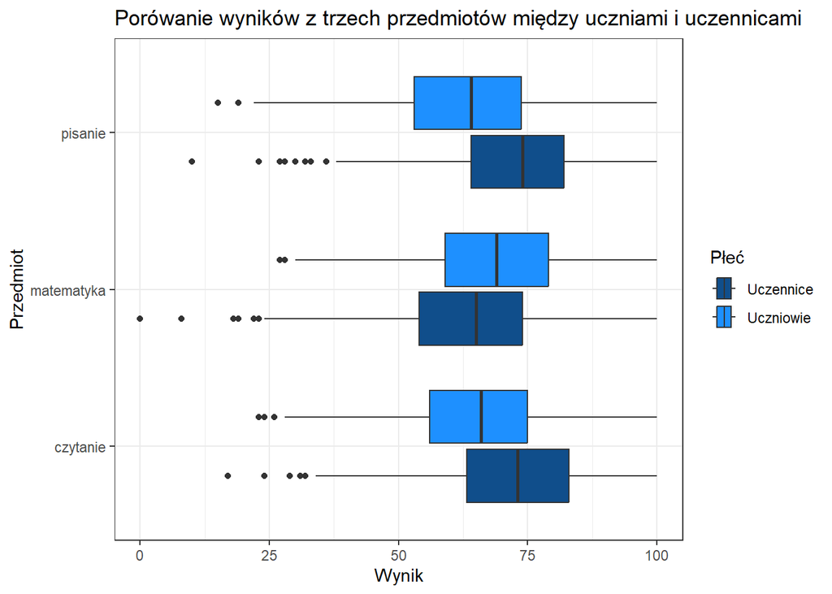

```r
# skorzystam z ramki danych którą stworzyłam w poprzednim zadaniu, bo w issues zostało zaznaczone, że mamy rozdzielić wyniki na rodzaje przedmiotów
df1 %>%
  ggplot(aes(x=wynik, y=przedmiot, fill=gender))+
  geom_boxplot()+
  labs(x="Wynik",
       y="Przedmiot",
       title="Porówanie wyników z trzech przedmiotów między uczniami i uczennicami")+
  scale_fill_manual(name = "Płeć", labels = c('female'='Uczennice', 'male'='Uczniowie'), values=c('dodgerblue4', 'dodgerblue'))+
  theme_bw()
```

**Komentarz:** Tak, dla każdego z przedmiotów widać różnicę w wynikach między uczniami i uczennicami. Dla pisania i czytania, to kobiety mają więcej dobrych wyników. Z kolei z matematyki to mężczyźni mają zauważalnie więcej dobrych wyników.

## Zadanie 3

Czy uczniowie, którzy ukończyli kurs przygotowawczy, osiągają lepsze wyniki niż pozostali?

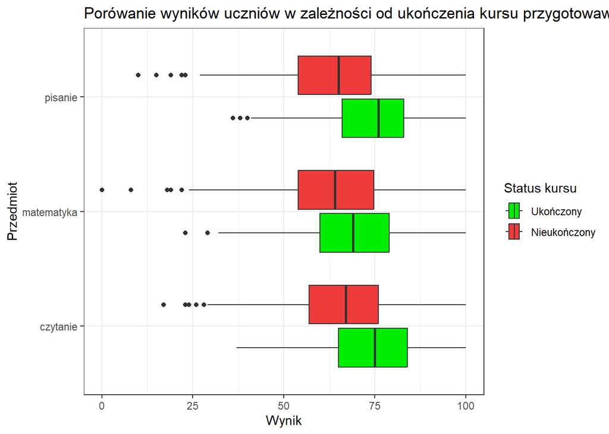

```r
df1 %>%
  ggplot(aes(x=wynik, y=przedmiot, fill=test.preparation.course))+
  geom_boxplot()+
  labs(x="Wynik",
       y="Przedmiot",
       title="Porówanie wyników uczniów w zależności od ukończenia kursu przygotowawczego")+
  scale_fill_manual(name = "Status kursu", labels = c('completed'='Ukończony', 'none'='Nieukończony'), values=c('green2', 'brown2'))+
  theme_bw()
```

**Komentarz:** Tak, z każdego z trzech przedmiotów, uczniowie, którzy ukończyli kurs przygotowawczy uzyskali wyższe wyniki od pozostałych.

## Zadanie 4

Jaki jest związek między poziomem wykształcenia rodziców a średnimi wynikami uczniów?

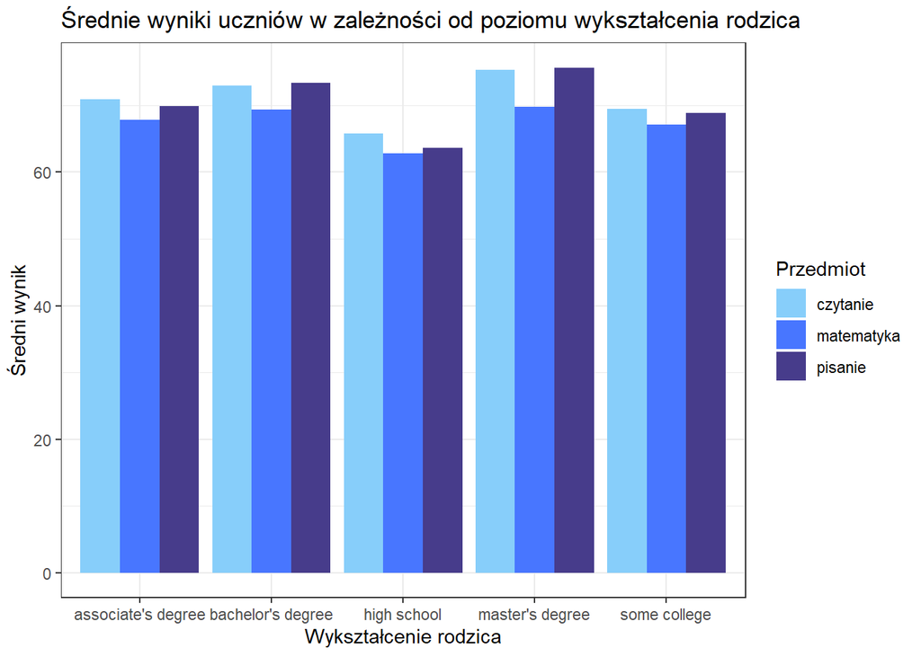

```r
#musimy zagregowac dane czyli m.in. polaczyc ze soba wartosci z high school i some high school gdyż znaczy to to samo - ukończenie liceum

df4 <- df1 %>%
  mutate(parental.level.of.education=case_when(parental.level.of.education %in% c("some high school", "high school") ~ "high school", TRUE ~parental.level.of.education)) %>%
  group_by(parental.level.of.education, przedmiot) %>%
  summarise(sredni_wynik = mean(wynik, na.rm=TRUE))

df4 %>%
  ggplot(aes(x=parental.level.of.education, y=sredni_wynik, fill=przedmiot))+
  geom_col(position = "dodge")+
  labs(x="Wykształcenie rodzica",
       y="Średni wynik",
       title="Średnie wyniki uczniów w zależności od poziomu wykształcenia rodzica", fill="Przedmiot")+
  scale_fill_manual(values = c('lightskyblue', 'royalblue1', 'slateblue4'))+
  theme_bw()
```

**Komentarz:** Średnie wyniki uczniów z każdego z trzech przedmiotów są najniższe, gdy ich rodzice zakończyli swoją edukację na poziomie liceum. Z kolei najwyższe średnie wyniki są dla tych uczniów, których rodzice są po magisterce.

## Zadanie 5

Czy płeć i wykształcenie rodzica wpływa na wynik z matematyki?

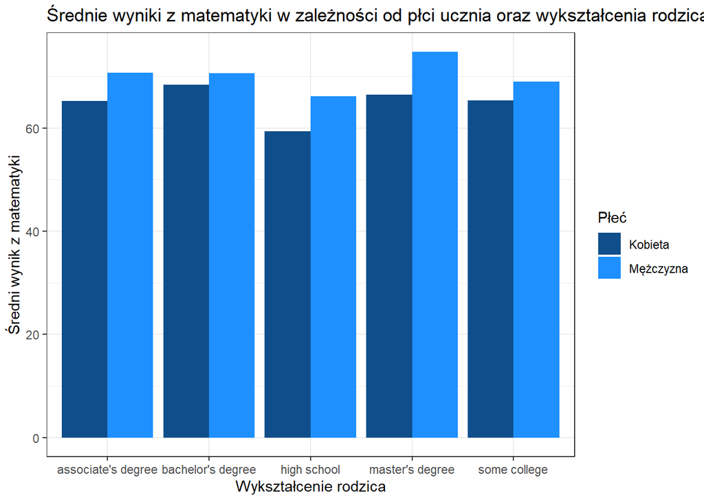

```r
df5 <- df1 %>%
  filter(przedmiot == 'matematyka') %>%
  mutate(parental.level.of.education=case_when(parental.level.of.education %in% c("some high school", "high school") ~ "high school", TRUE ~parental.level.of.education)) %>%
  group_by(parental.level.of.education, gender) %>%
  summarise(sredni_wynik = mean(wynik, na.rm=TRUE))

df5 %>%
  ggplot(aes(x=parental.level.of.education, y=sredni_wynik, fill=gender))+
  geom_col(position = "dodge")+
  labs(x="Wykształcenie rodzica",
       y="Średni wynik z matematyki",
       title="Średnie wyniki z matematyki w zależności od płci ucznia oraz wykształcenia rodzica", fill="Płeć")+
  scale_fill_manual(values=c('dodgerblue4', 'dodgerblue'), labels = c('female'='Kobieta', 'male'='Mężczyzna'))+
  theme_bw()
```

**Komentarz:** Tak, na podstawie analizy wykresu można stwierdzić, że płeć i wykształcenie rodzica wpływa na wynik z matematyki. Średnie wyniki z matematyki są wyższe dla uczniów płci męskiej. Dla kobiet, gdy rodzic ukończył studia licencjackie średni wynik jest najwyższy. Z kolei dla mężczyzn ten wynik jest najwyższy, gdy rodzice mają ukończone studia magisterskie. Dla obu płci najniższe wyniki są, gdy rodzice zakończyli edukację na poziomie liceum.

## Zadanie 6

Czy istnieje zależność między wynikami z matematyki a wynikami z czytania lub pisania?

```r
library(forcats)
```

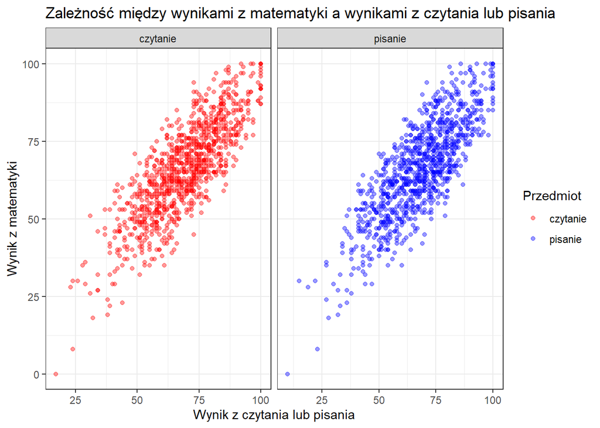

```r
df6 <- df %>%
  pivot_longer(c(reading.score, writing.score), names_to="przedmiot", values_to="wynik") %>%
  mutate(przedmiot = case_when(przedmiot == 'reading.score' ~ 'czytanie',
                                 TRUE ~ 'pisanie'))

df6 %>%
  ggplot(aes(x=wynik, y=math.score, color=przedmiot))+
  geom_point(alpha=0.4)+
  facet_wrap(~ przedmiot, scales = "free_x")+
  labs(title = "Zależność między wynikami z matematyki a wynikami z czytania lub pisania",
       y = "Wynik z matematyki",
       x = "Wynik z czytania lub pisania",
       color = "Przedmiot")+
  scale_color_manual(values=c('red', 'blue'))+
  theme_bw()
```

**Komentarz:** Tak istnieje zależność między wynikami z matematyki a wynikami z czytania lub pisania. Wraz ze wzrostem wyników z pozostałych dwóch przedmiotów, rośnie też wynik z matematyki. Zatem uczniowie, którzy radzą sobie z czytaniem i pisaniem są zazwyczaj też dobrzy z matematyki.